# Risk Factor Analysis

## Outcome Variable

**Outcome Variable:** y_rate_len

## Predictor Variables

**Intervention Variable:** fhtcm

**Adjustment Set:**

- arm
- W_mage
- W_fage
- meducyrs
- feducyrs
- W_mhtcm
- W_mwtkg
- W_mbmi
- single
- delta_W_fage
- delta_meducyrs
- delta_feducyrs
- delta_W_mhtcm
- delta_W_mwtkg
- delta_W_mbmi
- delta_single

## Stratifying Variables

The analysis was stratified on these variable(s):

- agecat
- studyid
- country

## Data Summary

| agecat | studyid | country | fhtcm | n_cell | n |
| --- | --- | --- | --- | --- | --- |
| 0-3 months | ki1119695-PROBIT | BELARUS | [160-170) | 1277 | 11500 |
| 0-3 months | ki1119695-PROBIT | BELARUS | <160 | 52 | 11500 |
| 0-3 months | ki1119695-PROBIT | BELARUS | >=170 | 10171 | 11500 |
| 0-3 months | ki1101329-Keneba | GAMBIA | [160-170) | 529 | 965 |
| 0-3 months | ki1101329-Keneba | GAMBIA | <160 | 23 | 965 |
| 0-3 months | ki1101329-Keneba | GAMBIA | >=170 | 413 | 965 |
| 0-3 months | ki1135781-COHORTS | GUATEMALA | [160-170) | 88 | 180 |
| 0-3 months | ki1135781-COHORTS | GUATEMALA | <160 | 80 | 180 |
| 0-3 months | ki1135781-COHORTS | GUATEMALA | >=170 | 12 | 180 |
| 0-3 months | ki1000304b-SAS-CompFeed | INDIA | [160-170) | 412 | 716 |
| 0-3 months | ki1000304b-SAS-CompFeed | INDIA | <160 | 109 | 716 |
| 0-3 months | ki1000304b-SAS-CompFeed | INDIA | >=170 | 195 | 716 |
| 3-6 months | ki1119695-PROBIT | BELARUS | [160-170) | 1117 | 10104 |
| 3-6 months | ki1119695-PROBIT | BELARUS | <160 | 45 | 10104 |
| 3-6 months | ki1119695-PROBIT | BELARUS | >=170 | 8942 | 10104 |
| 3-6 months | ki1101329-Keneba | GAMBIA | [160-170) | 569 | 1037 |
| 3-6 months | ki1101329-Keneba | GAMBIA | <160 | 24 | 1037 |
| 3-6 months | ki1101329-Keneba | GAMBIA | >=170 | 444 | 1037 |
| 3-6 months | ki1135781-COHORTS | GUATEMALA | [160-170) | 131 | 261 |
| 3-6 months | ki1135781-COHORTS | GUATEMALA | <160 | 111 | 261 |
| 3-6 months | ki1135781-COHORTS | GUATEMALA | >=170 | 19 | 261 |
| 3-6 months | ki1000304b-SAS-CompFeed | INDIA | [160-170) | 389 | 682 |
| 3-6 months | ki1000304b-SAS-CompFeed | INDIA | <160 | 102 | 682 |
| 3-6 months | ki1000304b-SAS-CompFeed | INDIA | >=170 | 191 | 682 |
| 6-12 months | ki1119695-PROBIT | BELARUS | [160-170) | 1089 | 9870 |
| 6-12 months | ki1119695-PROBIT | BELARUS | <160 | 42 | 9870 |
| 6-12 months | ki1119695-PROBIT | BELARUS | >=170 | 8739 | 9870 |
| 6-12 months | ki1101329-Keneba | GAMBIA | [160-170) | 555 | 1005 |
| 6-12 months | ki1101329-Keneba | GAMBIA | <160 | 25 | 1005 |
| 6-12 months | ki1101329-Keneba | GAMBIA | >=170 | 425 | 1005 |
| 6-12 months | ki1135781-COHORTS | GUATEMALA | [160-170) | 164 | 329 |
| 6-12 months | ki1135781-COHORTS | GUATEMALA | <160 | 142 | 329 |
| 6-12 months | ki1135781-COHORTS | GUATEMALA | >=170 | 23 | 329 |
| 6-12 months | ki1000304b-SAS-CompFeed | INDIA | [160-170) | 387 | 679 |
| 6-12 months | ki1000304b-SAS-CompFeed | INDIA | <160 | 94 | 679 |
| 6-12 months | ki1000304b-SAS-CompFeed | INDIA | >=170 | 198 | 679 |
| 6-12 months | ki1000304b-SAS-FoodSuppl | INDIA | [160-170) | 199 | 328 |
| 6-12 months | ki1000304b-SAS-FoodSuppl | INDIA | <160 | 85 | 328 |
| 6-12 months | ki1000304b-SAS-FoodSuppl | INDIA | >=170 | 44 | 328 |
| 12-24 months | ki1119695-PROBIT | BELARUS | [160-170) | 253 | 2320 |
| 12-24 months | ki1119695-PROBIT | BELARUS | <160 | 15 | 2320 |
| 12-24 months | ki1119695-PROBIT | BELARUS | >=170 | 2052 | 2320 |
| 12-24 months | ki1101329-Keneba | GAMBIA | [160-170) | 527 | 931 |
| 12-24 months | ki1101329-Keneba | GAMBIA | <160 | 21 | 931 |
| 12-24 months | ki1101329-Keneba | GAMBIA | >=170 | 383 | 931 |
| 12-24 months | ki1135781-COHORTS | GUATEMALA | [160-170) | 206 | 421 |
| 12-24 months | ki1135781-COHORTS | GUATEMALA | <160 | 183 | 421 |
| 12-24 months | ki1135781-COHORTS | GUATEMALA | >=170 | 32 | 421 |

The following strata were considered:

- agecat: 0-3 months, studyid: ki1000304b-SAS-CompFeed, country: INDIA
- agecat: 0-3 months, studyid: ki1101329-Keneba, country: GAMBIA
- agecat: 0-3 months, studyid: ki1119695-PROBIT, country: BELARUS
- agecat: 0-3 months, studyid: ki1135781-COHORTS, country: GUATEMALA
- agecat: 12-24 months, studyid: ki1101329-Keneba, country: GAMBIA
- agecat: 12-24 months, studyid: ki1119695-PROBIT, country: BELARUS
- agecat: 12-24 months, studyid: ki1135781-COHORTS, country: GUATEMALA
- agecat: 3-6 months, studyid: ki1000304b-SAS-CompFeed, country: INDIA
- agecat: 3-6 months, studyid: ki1101329-Keneba, country: GAMBIA
- agecat: 3-6 months, studyid: ki1119695-PROBIT, country: BELARUS
- agecat: 3-6 months, studyid: ki1135781-COHORTS, country: GUATEMALA
- agecat: 6-12 months, studyid: ki1000304b-SAS-CompFeed, country: INDIA
- agecat: 6-12 months, studyid: ki1000304b-SAS-FoodSuppl, country: INDIA
- agecat: 6-12 months, studyid: ki1101329-Keneba, country: GAMBIA
- agecat: 6-12 months, studyid: ki1119695-PROBIT, country: BELARUS
- agecat: 6-12 months, studyid: ki1135781-COHORTS, country: GUATEMALA

## Methods Detail

We’re interested in the causal parameters $E[Y_a]$ for all values of $a \in \mathcal{A}$. These parameters represent the mean outcome if, possibly contrary to fact, we intervened to set all units to have $A=a$. Under the randomization and positivity assumptions, these are identified by the statistical parameters $\psi_a=E_W[E_{Y|A,W}(Y|A=a,W)]$. In addition, we’re interested in the mean of $Y$, $E[Y]$ under no intervention (the observed mean). We will estimate these parameters by using SuperLearner to fit the relevant likelihood factors – $E_{Y|A,W}(Y|A=a,W)$ and $p(A=a|W)$, and then updating our likelihood fit using a joint TMLE.

For unadjusted analyses ($W=\{\}$), initial likelihoods were estimated using Lrnr_glm to estimate the simple $E(Y|A)$ and Lrnr_mean to estimate $p(A)$. For adjusted analyses, a small library containing Lrnr_glmnet, Lrnr_xgboost, and Lrnr_mean was used.

# Results Detail

## Results Plots

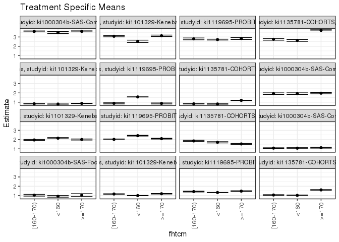

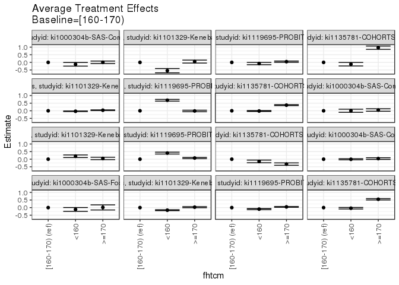

## Results Table

### Parameter: TSM

| agecat | studyid | country | intervention_level | baseline_level | estimate | ci_lower | ci_upper |
| --- | --- | --- | --- | --- | --- | --- | --- |
| 0-3 months | ki1000304b-SAS-CompFeed | INDIA | [160-170) | NA | 3.6018015 | 3.5526342 | 3.6509688 |
| 0-3 months | ki1000304b-SAS-CompFeed | INDIA | <160 | NA | 3.4753648 | 3.3635666 | 3.5871630 |
| 0-3 months | ki1000304b-SAS-CompFeed | INDIA | >=170 | NA | 3.6068830 | 3.5510059 | 3.6627601 |
| 0-3 months | ki1101329-Keneba | GAMBIA | [160-170) | NA | 3.0794493 | 3.0167511 | 3.1421475 |
| 0-3 months | ki1101329-Keneba | GAMBIA | <160 | NA | 2.5328001 | 2.4068376 | 2.6587626 |
| 0-3 months | ki1101329-Keneba | GAMBIA | >=170 | NA | 3.1308074 | 3.0535652 | 3.2080496 |
| 0-3 months | ki1119695-PROBIT | BELARUS | [160-170) | NA | 2.7974332 | 2.7007444 | 2.8941220 |
| 0-3 months | ki1119695-PROBIT | BELARUS | <160 | NA | 2.7194286 | 2.6702445 | 2.7686127 |
| 0-3 months | ki1119695-PROBIT | BELARUS | >=170 | NA | 2.8434241 | 2.7321394 | 2.9547087 |
| 0-3 months | ki1135781-COHORTS | GUATEMALA | [160-170) | NA | 2.7532918 | 2.6585637 | 2.8480200 |
| 0-3 months | ki1135781-COHORTS | GUATEMALA | <160 | NA | 2.6329225 | 2.5343139 | 2.7315310 |
| 0-3 months | ki1135781-COHORTS | GUATEMALA | >=170 | NA | 3.7191567 | 3.6596940 | 3.7786193 |
| 3-6 months | ki1000304b-SAS-CompFeed | INDIA | [160-170) | NA | 1.9233472 | 1.8394242 | 2.0072701 |
| 3-6 months | ki1000304b-SAS-CompFeed | INDIA | <160 | NA | 1.9258928 | 1.8391799 | 2.0126057 |
| 3-6 months | ki1000304b-SAS-CompFeed | INDIA | >=170 | NA | 1.9723202 | 1.9062533 | 2.0383871 |
| 3-6 months | ki1101329-Keneba | GAMBIA | [160-170) | NA | 1.9588251 | 1.9035835 | 2.0140668 |
| 3-6 months | ki1101329-Keneba | GAMBIA | <160 | NA | 2.1525412 | 2.0856227 | 2.2194597 |
| 3-6 months | ki1101329-Keneba | GAMBIA | >=170 | NA | 2.0084166 | 1.9497989 | 2.0670343 |
| 3-6 months | ki1119695-PROBIT | BELARUS | [160-170) | NA | 2.0214352 | 1.9772292 | 2.0656411 |
| 3-6 months | ki1119695-PROBIT | BELARUS | <160 | NA | 2.4225308 | 2.3831710 | 2.4618906 |
| 3-6 months | ki1119695-PROBIT | BELARUS | >=170 | NA | 2.0990885 | 2.0576122 | 2.1405648 |
| 3-6 months | ki1135781-COHORTS | GUATEMALA | [160-170) | NA | 1.8528290 | 1.7862891 | 1.9193689 |
| 3-6 months | ki1135781-COHORTS | GUATEMALA | <160 | NA | 1.7068267 | 1.6404787 | 1.7731747 |
| 3-6 months | ki1135781-COHORTS | GUATEMALA | >=170 | NA | 1.5304095 | 1.4803438 | 1.5804753 |
| 6-12 months | ki1000304b-SAS-CompFeed | INDIA | [160-170) | NA | 1.0802761 | 1.0440872 | 1.1164651 |
| 6-12 months | ki1000304b-SAS-CompFeed | INDIA | <160 | NA | 1.0741061 | 1.0162986 | 1.1319136 |
| 6-12 months | ki1000304b-SAS-CompFeed | INDIA | >=170 | NA | 1.1202773 | 1.0765622 | 1.1639923 |
| 6-12 months | ki1000304b-SAS-FoodSuppl | INDIA | [160-170) | NA | 1.0295274 | 0.9377834 | 1.1212715 |
| 6-12 months | ki1000304b-SAS-FoodSuppl | INDIA | <160 | NA | 0.9096433 | 0.8198301 | 0.9994566 |
| 6-12 months | ki1000304b-SAS-FoodSuppl | INDIA | >=170 | NA | 1.0419596 | 0.8897097 | 1.1942096 |
| 6-12 months | ki1101329-Keneba | GAMBIA | [160-170) | NA | 1.1619074 | 1.1379718 | 1.1858431 |
| 6-12 months | ki1101329-Keneba | GAMBIA | <160 | NA | 0.9916717 | 0.9712816 | 1.0120617 |
| 6-12 months | ki1101329-Keneba | GAMBIA | >=170 | NA | 1.1907562 | 1.1607824 | 1.2207299 |
| 6-12 months | ki1119695-PROBIT | BELARUS | [160-170) | NA | 1.4239886 | 1.3822654 | 1.4657117 |
| 6-12 months | ki1119695-PROBIT | BELARUS | <160 | NA | 1.3241849 | 1.3101802 | 1.3381897 |
| 6-12 months | ki1119695-PROBIT | BELARUS | >=170 | NA | 1.4708256 | 1.4323147 | 1.5093366 |
| 6-12 months | ki1135781-COHORTS | GUATEMALA | [160-170) | NA | 1.0535320 | 1.0206972 | 1.0863668 |
| 6-12 months | ki1135781-COHORTS | GUATEMALA | <160 | NA | 1.0136661 | 0.9770163 | 1.0503158 |
| 6-12 months | ki1135781-COHORTS | GUATEMALA | >=170 | NA | 1.6030347 | 1.5727958 | 1.6332736 |
| 12-24 months | ki1101329-Keneba | GAMBIA | [160-170) | NA | 0.8306251 | 0.8157572 | 0.8454929 |
| 12-24 months | ki1101329-Keneba | GAMBIA | <160 | NA | 0.7985069 | 0.7862736 | 0.8107402 |
| 12-24 months | ki1101329-Keneba | GAMBIA | >=170 | NA | 0.8684117 | 0.8508183 | 0.8860051 |
| 12-24 months | ki1119695-PROBIT | BELARUS | [160-170) | NA | 0.8761187 | 0.8189829 | 0.9332546 |
| 12-24 months | ki1119695-PROBIT | BELARUS | <160 | NA | 1.5688825 | 1.5579696 | 1.5797954 |
| 12-24 months | ki1119695-PROBIT | BELARUS | >=170 | NA | 0.8649315 | 0.8129690 | 0.9168940 |
| 12-24 months | ki1135781-COHORTS | GUATEMALA | [160-170) | NA | 0.8242227 | 0.8052383 | 0.8432071 |
| 12-24 months | ki1135781-COHORTS | GUATEMALA | <160 | NA | 0.8086492 | 0.7884110 | 0.8288875 |
| 12-24 months | ki1135781-COHORTS | GUATEMALA | >=170 | NA | 1.1943037 | 1.1729947 | 1.2156127 |

### Parameter: E(Y)

| agecat | studyid | country | intervention_level | baseline_level | estimate | ci_lower | ci_upper |
| --- | --- | --- | --- | --- | --- | --- | --- |
| 0-3 months | ki1000304b-SAS-CompFeed | INDIA | NA | NA | 3.5844413 | 3.5457307 | 3.6231519 |
| 0-3 months | ki1101329-Keneba | GAMBIA | NA | NA | 3.1289757 | 3.0738379 | 3.1841134 |
| 0-3 months | ki1119695-PROBIT | BELARUS | NA | NA | 2.8334708 | 2.7205961 | 2.9463455 |
| 0-3 months | ki1135781-COHORTS | GUATEMALA | NA | NA | 2.6646531 | 2.5748250 | 2.7544813 |
| 3-6 months | ki1000304b-SAS-CompFeed | INDIA | NA | NA | 1.9381168 | 1.8722991 | 2.0039344 |
| 3-6 months | ki1101329-Keneba | GAMBIA | NA | NA | 1.9794873 | 1.9347361 | 2.0242384 |
| 3-6 months | ki1119695-PROBIT | BELARUS | NA | NA | 2.0916969 | 2.0506004 | 2.1327933 |
| 3-6 months | ki1135781-COHORTS | GUATEMALA | NA | NA | 1.7979953 | 1.7423030 | 1.8536877 |
| 6-12 months | ki1000304b-SAS-CompFeed | INDIA | NA | NA | 1.0908364 | 1.0624756 | 1.1191972 |
| 6-12 months | ki1000304b-SAS-FoodSuppl | INDIA | NA | NA | 0.9947133 | 0.9228294 | 1.0665973 |
| 6-12 months | ki1101329-Keneba | GAMBIA | NA | NA | 1.1722791 | 1.1516434 | 1.1929147 |
| 6-12 months | ki1119695-PROBIT | BELARUS | NA | NA | 1.4698038 | 1.4307195 | 1.5088880 |
| 6-12 months | ki1135781-COHORTS | GUATEMALA | NA | NA | 0.9973638 | 0.9680912 | 1.0266364 |
| 12-24 months | ki1101329-Keneba | GAMBIA | NA | NA | 0.8443568 | 0.8321723 | 0.8565414 |
| 12-24 months | ki1119695-PROBIT | BELARUS | NA | NA | 0.8608646 | 0.8094654 | 0.9122639 |
| 12-24 months | ki1135781-COHORTS | GUATEMALA | NA | NA | 0.7934317 | 0.7769015 | 0.8099619 |

### Parameter: ATE

| agecat | studyid | country | intervention_level | baseline_level | estimate | ci_lower | ci_upper |
| --- | --- | --- | --- | --- | --- | --- | --- |
| 0-3 months | ki1000304b-SAS-CompFeed | INDIA | [160-170) | [160-170) | 0.0000000 | 0.0000000 | 0.0000000 |
| 0-3 months | ki1000304b-SAS-CompFeed | INDIA | <160 | [160-170) | -0.1264367 | -0.2467049 | -0.0061685 |
| 0-3 months | ki1000304b-SAS-CompFeed | INDIA | >=170 | [160-170) | 0.0050815 | -0.0764922 | 0.0866553 |
| 0-3 months | ki1101329-Keneba | GAMBIA | [160-170) | [160-170) | 0.0000000 | 0.0000000 | 0.0000000 |
| 0-3 months | ki1101329-Keneba | GAMBIA | <160 | [160-170) | -0.5466492 | -0.6859036 | -0.4073948 |
| 0-3 months | ki1101329-Keneba | GAMBIA | >=170 | [160-170) | 0.0513581 | -0.0456780 | 0.1483942 |
| 0-3 months | ki1119695-PROBIT | BELARUS | [160-170) | [160-170) | 0.0000000 | 0.0000000 | 0.0000000 |
| 0-3 months | ki1119695-PROBIT | BELARUS | <160 | [160-170) | -0.0780046 | -0.1542776 | -0.0017317 |
| 0-3 months | ki1119695-PROBIT | BELARUS | >=170 | [160-170) | 0.0459908 | 0.0043542 | 0.0876274 |
| 0-3 months | ki1135781-COHORTS | GUATEMALA | [160-170) | [160-170) | 0.0000000 | 0.0000000 | 0.0000000 |
| 0-3 months | ki1135781-COHORTS | GUATEMALA | <160 | [160-170) | -0.1203694 | -0.2366042 | -0.0041346 |
| 0-3 months | ki1135781-COHORTS | GUATEMALA | >=170 | [160-170) | 0.9658648 | 0.8578760 | 1.0738536 |
| 3-6 months | ki1000304b-SAS-CompFeed | INDIA | [160-170) | [160-170) | 0.0000000 | 0.0000000 | 0.0000000 |
| 3-6 months | ki1000304b-SAS-CompFeed | INDIA | <160 | [160-170) | 0.0025456 | -0.0995040 | 0.1045952 |
| 3-6 months | ki1000304b-SAS-CompFeed | INDIA | >=170 | [160-170) | 0.0489730 | -0.0312011 | 0.1291470 |
| 3-6 months | ki1101329-Keneba | GAMBIA | [160-170) | [160-170) | 0.0000000 | 0.0000000 | 0.0000000 |
| 3-6 months | ki1101329-Keneba | GAMBIA | <160 | [160-170) | 0.1937161 | 0.1087195 | 0.2787126 |
| 3-6 months | ki1101329-Keneba | GAMBIA | >=170 | [160-170) | 0.0495914 | -0.0299944 | 0.1291772 |
| 3-6 months | ki1119695-PROBIT | BELARUS | [160-170) | [160-170) | 0.0000000 | 0.0000000 | 0.0000000 |
| 3-6 months | ki1119695-PROBIT | BELARUS | <160 | [160-170) | 0.4010956 | 0.3404413 | 0.4617500 |
| 3-6 months | ki1119695-PROBIT | BELARUS | >=170 | [160-170) | 0.0776533 | 0.0375071 | 0.1177996 |
| 3-6 months | ki1135781-COHORTS | GUATEMALA | [160-170) | [160-170) | 0.0000000 | 0.0000000 | 0.0000000 |
| 3-6 months | ki1135781-COHORTS | GUATEMALA | <160 | [160-170) | -0.1460023 | -0.2339346 | -0.0580701 |
| 3-6 months | ki1135781-COHORTS | GUATEMALA | >=170 | [160-170) | -0.3224195 | -0.4006824 | -0.2441566 |
| 6-12 months | ki1000304b-SAS-CompFeed | INDIA | [160-170) | [160-170) | 0.0000000 | 0.0000000 | 0.0000000 |
| 6-12 months | ki1000304b-SAS-CompFeed | INDIA | <160 | [160-170) | -0.0061700 | -0.0415240 | 0.0291839 |
| 6-12 months | ki1000304b-SAS-CompFeed | INDIA | >=170 | [160-170) | 0.0400011 | -0.0161816 | 0.0961839 |
| 6-12 months | ki1000304b-SAS-FoodSuppl | INDIA | [160-170) | [160-170) | 0.0000000 | 0.0000000 | 0.0000000 |
| 6-12 months | ki1000304b-SAS-FoodSuppl | INDIA | <160 | [160-170) | -0.1198841 | -0.2449813 | 0.0052131 |
| 6-12 months | ki1000304b-SAS-FoodSuppl | INDIA | >=170 | [160-170) | 0.0124322 | -0.1548846 | 0.1797490 |
| 6-12 months | ki1101329-Keneba | GAMBIA | [160-170) | [160-170) | 0.0000000 | 0.0000000 | 0.0000000 |
| 6-12 months | ki1101329-Keneba | GAMBIA | <160 | [160-170) | -0.1702358 | -0.2005685 | -0.1399031 |
| 6-12 months | ki1101329-Keneba | GAMBIA | >=170 | [160-170) | 0.0288487 | -0.0087270 | 0.0664245 |
| 6-12 months | ki1119695-PROBIT | BELARUS | [160-170) | [160-170) | 0.0000000 | 0.0000000 | 0.0000000 |
| 6-12 months | ki1119695-PROBIT | BELARUS | <160 | [160-170) | -0.0998036 | -0.1366865 | -0.0629207 |
| 6-12 months | ki1119695-PROBIT | BELARUS | >=170 | [160-170) | 0.0468371 | 0.0168386 | 0.0768356 |
| 6-12 months | ki1135781-COHORTS | GUATEMALA | [160-170) | [160-170) | 0.0000000 | 0.0000000 | 0.0000000 |
| 6-12 months | ki1135781-COHORTS | GUATEMALA | <160 | [160-170) | -0.0398660 | -0.0895519 | 0.0098200 |
| 6-12 months | ki1135781-COHORTS | GUATEMALA | >=170 | [160-170) | 0.5495027 | 0.5039864 | 0.5950189 |
| 12-24 months | ki1101329-Keneba | GAMBIA | [160-170) | [160-170) | 0.0000000 | 0.0000000 | 0.0000000 |
| 12-24 months | ki1101329-Keneba | GAMBIA | <160 | [160-170) | -0.0321181 | -0.0510321 | -0.0132042 |
| 12-24 months | ki1101329-Keneba | GAMBIA | >=170 | [160-170) | 0.0377867 | 0.0150719 | 0.0605014 |
| 12-24 months | ki1119695-PROBIT | BELARUS | [160-170) | [160-170) | 0.0000000 | 0.0000000 | 0.0000000 |
| 12-24 months | ki1119695-PROBIT | BELARUS | <160 | [160-170) | 0.6927637 | 0.6345580 | 0.7509695 |
| 12-24 months | ki1119695-PROBIT | BELARUS | >=170 | [160-170) | -0.0111872 | -0.0617597 | 0.0393853 |
| 12-24 months | ki1135781-COHORTS | GUATEMALA | [160-170) | [160-170) | 0.0000000 | 0.0000000 | 0.0000000 |
| 12-24 months | ki1135781-COHORTS | GUATEMALA | <160 | [160-170) | -0.0155735 | -0.0434023 | 0.0122553 |
| 12-24 months | ki1135781-COHORTS | GUATEMALA | >=170 | [160-170) | 0.3700810 | 0.3400723 | 0.4000897 |